# 16S Data Processing Training

Author

Katie McCauley from the Bioinformatics and Computational Biosciences Branch (BCBB)

Thank you for joining us for this 16S rRNA microbiome data processing tutorial! Before we jump in, let’s start by going over our learning objectives for the technical component.

- Identify Primers and/or Adapters
- Check the Quality of Microbiome Data
- Develop Amplicon Sequence Variants (ASVs) using the Divisive Amplicon Denoising Algorithm 2 (DADA2)
- Assign Taxonomy
- Check for Chimeras
- Make a Phylogenetic Tree
- Collate Data in a `phyloseq` Object

This tutorial is designed to introduce you to the steps involved in generating data from DADA2. While you may never actually create an ASV table using R code again (perhaps preferring Nephele’s code-free DADA2 pipeline[^1]), we will hopefully introduce you to the steps involved and points to watch out for or consider when choosing parameters or evaluating your results.

## 1 Quick Note about ASVs vs OTUs

What we’ll cover today are considered **Amplicon Sequence Variants** or **Sequence Variants** because they have the ability to differ by as little as one nucleotide (we’ll cover how this happens later). Before DADA2 was widely accepted, though, the field primarily used **Operational Taxonomic Units** or **OTUs**. This was based on clustering sequences with 97% similarity. Meaning:

- Take your most frequent sequence and consider it the first “seed”
- Take your next most-frequent sequence and determine how similar it is to the first sequence. If it’s 97% similar, consider it the “same” as the first sequence and if it’s less than that, consider it a new “seed”
- Repeat for all dereplicated sequences, checking against all other “seed” sequences

The 97% cutoff was chosen because it was presumed to account for potential PCR error in the sequence data, but often was fairly greedy. The figure below from Benjamin Callahan’s supplemental material for the DADA2 paper[^2] help describe this comparison:

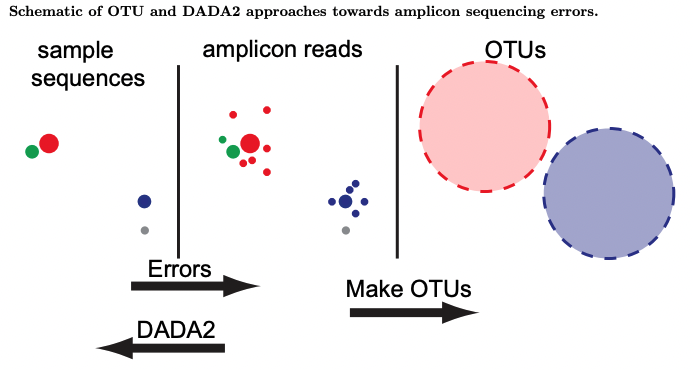

Comparing OTUs to ASVs

## 2 A Primer on Sequencing

[A short video from Illumina on “Sequencing by Synthesis”](https://www.youtube.com/watch?v=fCd6B5HRaZ8)

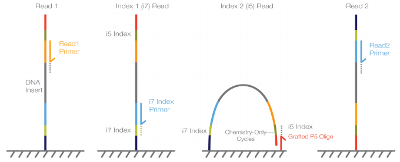

Indexed Sequencing Overview

When the data is pulled from the sequencer, it typically arrives in BCL format, which is a highly compressed and proprietary Illumina format from which we need to create human- and computer-readable files (FASTQ). Illumina now frequently provides individual forward and reverse sequence files for each sample (called “Demultiplexed”), and this is the format that gets uploaded to public repositories like the Sequence Read Archive (SRA) or the European Nucleotide Archive (ENA).

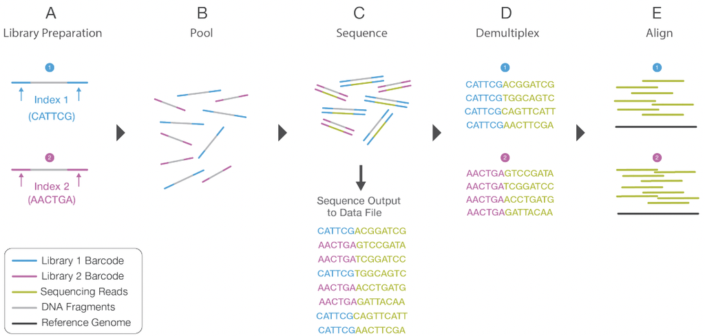

Library Multiplexing Overview

This is what a “FASTQ” file ends up looking like:

```
@M03213:59:000000000-AWR6D:1:1101:12406:1145 2:N:0:NCCTGAGC+NTATTAAG
NGACTACTGGGGTTTCTAATCCTGTTTGCTCCCCACGCTTTCGCACATGAGCGTCAGTAC…
+
#8ACCGGGGGGGFFGGGGFGGGGGGGGGGGGGGGGGGGGGGGEGGFFGGGGGGGGGGGGGGFGFFGG<E#:BFFGGGFGGGGGCGGFEFGFFGGGGG<CFFCFGGGGGG#99@FFGGEGBGGFGGF8CFFFEFGGG<=9DC>DDGGD?C=,;EGFGBFDGFFGGGGCC;@EEFGGGGFGGGGGGGGGFGGFDEGGGAADE5;EEB*07/9<FFCFGFGD@=@EDFF>7>9;C?E</2(2.6;<=)7,9<?(*)6(7,,(-
@M03213:59:000000000-AWR6D:1:1101:9817:1174 2:N:0:NCCTGAGC+CTATTAAG
NGACTACTGGGGTTTCTAATCCTGTTCGCTACCCACGCTTTCGAGCCTCAGCGTCAGTTA…
+
#8ACCGGGGGGGFCGGGGGGGGGGGGFGGGGGGGGGGGGGGGGFGGGGFGFFGGGFGFGGGGGGG7CFGCFFGGGGBEGGGGGGGG?EGGGGGFGGGGGGGGFGGGGGGGE@DFAFGGGFGEGGGGGGGGGF<,@,DDFGGDGDG=EFGGGFF,=D?8DF,?EGGCFCF,DFFGGFCDGFGG8@E3<?FF8DG8BFDFEEFCBEFA7;@6;A@CGGC7915>8)702/8:4*4A+7=;((/(,/6<29(((*.//,,/)/(
```

## 3 Find and Organize our Data

Let’s dive into some data and generate some ASVs! First things first: we need to organize our sequencing data. If you didn’t bring your own data, you will find the files that we work with today under `raw_files`, and we will use this location throughout the tutorial today. If you did bring your own data, figure out where they live and put that location here:

```r
data_location <- "~/OneDrive/training/16S-data-processing/raw_files/"
```

The data we’re working with today comes from a small subset of publicly available samples (Accession `PRJEB42394`) analyzed here[^3] and utilizes 16S rRNA V4 sequencing of nasal microbiome samples from children with asthma. Samples were sequenced on the NextSeq 500.

I have another markdown file with a tutorial for how I found and downloaded these files if you’re interested (See `DownloadingFromSRA.html`). For now, I have selected a handful of samples from this study that we will use to create an ASV/OTU table with DADA2 and those files reside in the `raw_files` directory we linked to above.

```r
library(dada2)
read_indicator <- "_1"
all_fastqs <- list.files(data_location, full.names = T)
all_fastqs[1:15]
```

```
 [1] "/Users/mccauleyke/OneDrive/training/16S-data-processing/raw_files//ERR5083021_1.fastq.gz"
 [2] "/Users/mccauleyke/OneDrive/training/16S-data-processing/raw_files//ERR5083021_2.fastq.gz"
 [3] "/Users/mccauleyke/OneDrive/training/16S-data-processing/raw_files//ERR5083022_1.fastq.gz"
 [4] "/Users/mccauleyke/OneDrive/training/16S-data-processing/raw_files//ERR5083022_2.fastq.gz"
 [5] "/Users/mccauleyke/OneDrive/training/16S-data-processing/raw_files//ERR5083023_1.fastq.gz"
 [6] "/Users/mccauleyke/OneDrive/training/16S-data-processing/raw_files//ERR5083023_2.fastq.gz"
 [7] "/Users/mccauleyke/OneDrive/training/16S-data-processing/raw_files//ERR5083024_1.fastq.gz"
 [8] "/Users/mccauleyke/OneDrive/training/16S-data-processing/raw_files//ERR5083024_2.fastq.gz"
 [9] "/Users/mccauleyke/OneDrive/training/16S-data-processing/raw_files//ERR5083025_1.fastq.gz"
[10] "/Users/mccauleyke/OneDrive/training/16S-data-processing/raw_files//ERR5083025_2.fastq.gz"
[11] "/Users/mccauleyke/OneDrive/training/16S-data-processing/raw_files//ERR5083026_1.fastq.gz"
[12] "/Users/mccauleyke/OneDrive/training/16S-data-processing/raw_files//ERR5083026_2.fastq.gz"
[13] "/Users/mccauleyke/OneDrive/training/16S-data-processing/raw_files//ERR5083027_1.fastq.gz"
[14] "/Users/mccauleyke/OneDrive/training/16S-data-processing/raw_files//ERR5083027_2.fastq.gz"
[15] "/Users/mccauleyke/OneDrive/training/16S-data-processing/raw_files//ERR5083028_1.fastq.gz"
```

```r
r1_fastqs <- all_fastqs[grepl(read_indicator, all_fastqs)]
r2_fastqs <- all_fastqs[!grepl(read_indicator, all_fastqs)]
r1_fastqs[1:10]
```

```
 [1] "/Users/mccauleyke/OneDrive/training/16S-data-processing/raw_files//ERR5083021_1.fastq.gz"
 [2] "/Users/mccauleyke/OneDrive/training/16S-data-processing/raw_files//ERR5083022_1.fastq.gz"
 [3] "/Users/mccauleyke/OneDrive/training/16S-data-processing/raw_files//ERR5083023_1.fastq.gz"
 [4] "/Users/mccauleyke/OneDrive/training/16S-data-processing/raw_files//ERR5083024_1.fastq.gz"
 [5] "/Users/mccauleyke/OneDrive/training/16S-data-processing/raw_files//ERR5083025_1.fastq.gz"
 [6] "/Users/mccauleyke/OneDrive/training/16S-data-processing/raw_files//ERR5083026_1.fastq.gz"
 [7] "/Users/mccauleyke/OneDrive/training/16S-data-processing/raw_files//ERR5083027_1.fastq.gz"
 [8] "/Users/mccauleyke/OneDrive/training/16S-data-processing/raw_files//ERR5083028_1.fastq.gz"
 [9] "/Users/mccauleyke/OneDrive/training/16S-data-processing/raw_files//ERR5083029_1.fastq.gz"
[10] "/Users/mccauleyke/OneDrive/training/16S-data-processing/raw_files//ERR5083030_1.fastq.gz"
```

```r
r2_fastqs[1:10]
```

```
 [1] "/Users/mccauleyke/OneDrive/training/16S-data-processing/raw_files//ERR5083021_2.fastq.gz"
 [2] "/Users/mccauleyke/OneDrive/training/16S-data-processing/raw_files//ERR5083022_2.fastq.gz"
 [3] "/Users/mccauleyke/OneDrive/training/16S-data-processing/raw_files//ERR5083023_2.fastq.gz"
 [4] "/Users/mccauleyke/OneDrive/training/16S-data-processing/raw_files//ERR5083024_2.fastq.gz"
 [5] "/Users/mccauleyke/OneDrive/training/16S-data-processing/raw_files//ERR5083025_2.fastq.gz"
 [6] "/Users/mccauleyke/OneDrive/training/16S-data-processing/raw_files//ERR5083026_2.fastq.gz"
 [7] "/Users/mccauleyke/OneDrive/training/16S-data-processing/raw_files//ERR5083027_2.fastq.gz"
 [8] "/Users/mccauleyke/OneDrive/training/16S-data-processing/raw_files//ERR5083028_2.fastq.gz"
 [9] "/Users/mccauleyke/OneDrive/training/16S-data-processing/raw_files//ERR5083029_2.fastq.gz"
[10] "/Users/mccauleyke/OneDrive/training/16S-data-processing/raw_files//ERR5083030_2.fastq.gz"
```

## 4 Identifying Primers and Adapters

Primers and adapters are typically present in sequence data as artifacts of the sequencing process, and need to be removed before we start processing our data. For the purposes of our discussion, I’m going to use R to ask if there are any primers in our sequencing data. This dataset examines the V4 region of the 16S rRNA gene, and uses 515F and 806R primers. You can get the primer sequences from the Earth Microbiome Project’s website (https://earthmicrobiome.org/protocols-and-standards/16s/). You may need to obtain different sequences for your primer strategy, but the overall code to search for our (known) primers remains the same.

Note that **Primer sequences** are at the beginning of the sequence read.

```r
library(ShortRead)
library(Biostrings)
FWD <- "GTGCCAGCMGCCGCGGTAA"
REV <- "GGACTACHVGGGTWTCTAAT"

primerHits <- function(primer, fn) {
  start_seq <- sread(readFastq(fn))
  start_seq <- subseq(start_seq, start=1, end=length(primer)+1)
  nhits <- vcountPattern(primer, start_seq, fixed = FALSE)
  return(sum(nhits > 0))
}
sapply(FWD, primerHits, r1_fastqs[1:10])
sapply(REV, primerHits, r2_fastqs[1:10])
```

[output not shown]

**Adapters**, however are typically at the end of the read. You can search for them with tools like FASTQC[^4], which is used in Nephele’s Pre-Process/Quality Check pipeline (https://nephele.niaid.nih.gov/details_qc/). This provides a good first-pass of data in the early stages and I’ll walk through a demo.

Most often, adapters are found at the end of the read because of “read-through”. This is what happens when the length of the read is longer than the actual size of the region of interest. For instance, if you were sequencing the V4 region, which is 253bp, but you used a 600-cycle MiSeq (which produces 300 base forward and reverse read, you would read into the adapter.

Since the sequencing methods used for these samples resulted in reads that are shorter than 253 bases and the FASTQC analysis didn’t identify any adapters, we can move forward!

**Quiz**

For the following scenarios, would you expect to find adapters? If so, what adapter removal strategies could work?

1. V4 region (253bp) on a 2x150 NextSeq run
2. V1-V3 region (~480bp) on a 2x300 MiSeq run
3. V4 region (253bp) on a 2x300 MiSeq run
4. *BONUS* ITS2 (160-390bp) on a 2x300 MiSeq run

## 5 Quality Filtering and Trimming

While DADA2 will physically correct the reads based on quality scores, it is helpful to have relatively high-quality data going in. This is a good time to review the multiQC report to help us identify areas we may want to have impact on.

**Quiz**

Review the QC report. Notice what MultiQC highlights as “good” or “bad”. Do you agree?

Before we start processing, we need somewhere for our filtered reads to go, so we do some housekeeping. Keep in mind that I’m performing very simple string modification, but you may need to do something more complex for your data and samples.

```r
r1_filt <- gsub("raw_files", "filtered", r1_fastqs)
r2_filt <- gsub("raw_files", "filtered", r2_fastqs)
## In my case, the filtered directory could exist before I make the document
## The `unlink` function just makes sure it's not there when I run filterAndTrim
unlink("filtered/", recursive = T)
```

Given this information, we now use the `filterAndTrim` function to clean our data. There are several different terms you can use, and these can be reviewed with `?filterAndTrim`.

```r
out <- filterAndTrim(r1_fastqs, r1_filt, r2_fastqs, r2_filt,
                     maxN=0, maxEE=2, multithread = F,
                     verbose=T, rm.lowcomplex = 8, rm.phix = T)
```

```
Creating output directory: /Users/mccauleyke/OneDrive/training/16S-data-processing/filtered
```

```
Read in 184105 paired-sequences, output 158042 (85.8%) filtered paired-sequences.
```

```
Read in 215283 paired-sequences, output 178461 (82.9%) filtered paired-sequences.
```

```
Read in 188345 paired-sequences, output 161553 (85.8%) filtered paired-sequences.
```

```
Read in 228630 paired-sequences, output 198805 (87%) filtered paired-sequences.
```

```
Read in 208557 paired-sequences, output 171355 (82.2%) filtered paired-sequences.
```

```
Read in 221399 paired-sequences, output 172853 (78.1%) filtered paired-sequences.
```

```
Read in 206371 paired-sequences, output 169776 (82.3%) filtered paired-sequences.
```

```
Read in 258864 paired-sequences, output 222554 (86%) filtered paired-sequences.
```

```
Read in 248457 paired-sequences, output 204002 (82.1%) filtered paired-sequences.
```

```
Read in 232949 paired-sequences, output 199106 (85.5%) filtered paired-sequences.
```

```
Read in 192017 paired-sequences, output 156996 (81.8%) filtered paired-sequences.
```

```
Read in 182086 paired-sequences, output 147473 (81%) filtered paired-sequences.
```

```
Read in 268647 paired-sequences, output 228479 (85%) filtered paired-sequences.
```

```
Read in 237626 paired-sequences, output 188624 (79.4%) filtered paired-sequences.
```

```
Read in 329348 paired-sequences, output 268605 (81.6%) filtered paired-sequences.
```

```
Read in 289866 paired-sequences, output 248908 (85.9%) filtered paired-sequences.
```

```
Read in 259349 paired-sequences, output 216996 (83.7%) filtered paired-sequences.
```

```
Read in 283546 paired-sequences, output 245068 (86.4%) filtered paired-sequences.
```

```
Read in 255232 paired-sequences, output 215938 (84.6%) filtered paired-sequences.
```

```
Read in 318604 paired-sequences, output 262531 (82.4%) filtered paired-sequences.
```

```r
out
```

```
                      reads.in reads.out
ERR5083021_1.fastq.gz   184105    158042
ERR5083022_1.fastq.gz   215283    178461
ERR5083023_1.fastq.gz   188345    161553
ERR5083024_1.fastq.gz   228630    198805
ERR5083025_1.fastq.gz   208557    171355
ERR5083026_1.fastq.gz   221399    172853
ERR5083027_1.fastq.gz   206371    169776
ERR5083028_1.fastq.gz   258864    222554
ERR5083029_1.fastq.gz   248457    204002
ERR5083030_1.fastq.gz   232949    199106
ERR5083031_1.fastq.gz   192017    156996
ERR5083032_1.fastq.gz   182086    147473
ERR5083033_1.fastq.gz   268647    228479
ERR5083034_1.fastq.gz   237626    188624
ERR5083035_1.fastq.gz   329348    268605
ERR5083036_1.fastq.gz   289866    248908
ERR5083037_1.fastq.gz   259349    216996
ERR5083038_1.fastq.gz   283546    245068
ERR5083039_1.fastq.gz   255232    215938
ERR5083040_1.fastq.gz   318604    262531
```

**Quiz**

Under the following scenarios, would you expect *more* or *fewer* reads to pass QC?

1. truncQ = 25, minLen = 125 (default: truncQ = 2, minLen=20)
2. maxEE = 5
3. truncLen = c(150,125) (default: truncLen = 0)

If you have time, feel free to test these parameters!

## 6 Denoise Reads

To actually get to “sequence variants”, the DADA2 method uses a combination of building an “error” model to determine transition probabilities and an “abundance p-value”. This “p-value” functions under the null hypothesis that a sequence is too abundant to be explained by error alone. We don’t end up seeing these p-values, but can delve into objects if we’re ever curious.

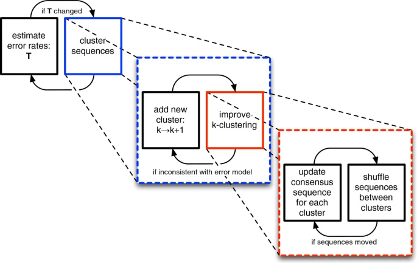

Schematic of the DADA Algorithm

If you want to learn more about the method, you can read either the DADA[^5] or the DADA2 papers[^6]

What we do first is train the algorithm on our current data so it knows how to apply error correction. Also, notice that only a portion of samples and sequences are used for training.

```r
r1_err <- learnErrors(r1_filt, multithread=F, verbose=T)
```

```
106615112 total bases in 696861 reads from 4 samples will be used for learning the error rates.
Initializing error rates to maximum possible estimate.
selfConsist step 1 ....
   selfConsist step 2
   selfConsist step 3
   selfConsist step 4
   selfConsist step 5
Convergence after  5  rounds.
```

```r
r2_err <- learnErrors(r2_filt, multithread=F, verbose=T)
```

```
106604635 total bases in 696861 reads from 4 samples will be used for learning the error rates.
Initializing error rates to maximum possible estimate.
selfConsist step 1 ....
   selfConsist step 2
   selfConsist step 3
   selfConsist step 4
   selfConsist step 5
   selfConsist step 6
   selfConsist step 7
Convergence after  7  rounds.
```

These plots tell us for each nucleotide transition(A2A, A2T, etc.), the average error frequency across quality scores. The observed values are the points, the red lines indicate expected values, and the final estimated error rates based on the model are the black lines.

While somewhat messy, they are still trending in the correct direction. As long as the model (black line) fits the black points, and the trend is generally negative across all transitions, DADA2 should perform as expected.

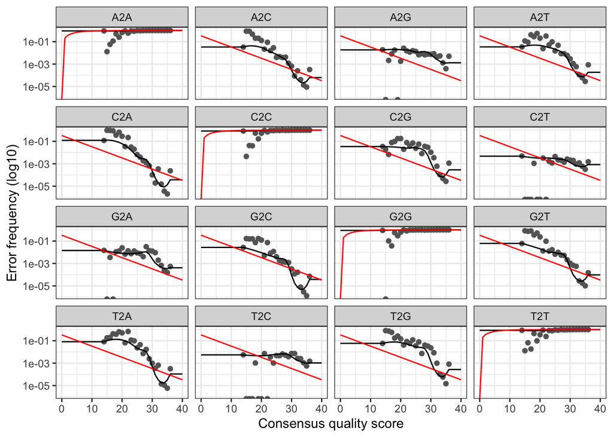

```r
plotErrors(r1_err, nominalQ = T)
```

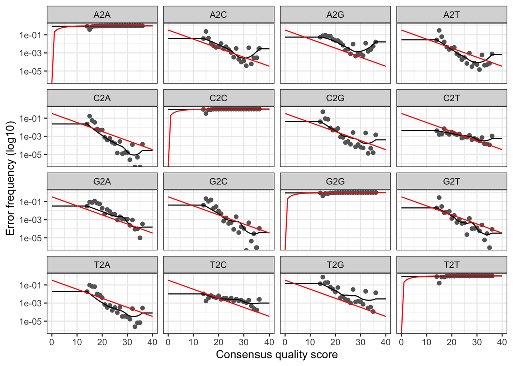

```r
plotErrors(r2_err, nominalQ = T)
```

Now we apply these error rates to our filtered data and perform the DADA2 denoising!

```r
r1_dada <- dada(r1_filt, r1_err)
```

```
Sample 1 - 158042 reads in 21438 unique sequences.
Sample 2 - 178461 reads in 25600 unique sequences.
Sample 3 - 161553 reads in 23661 unique sequences.
Sample 4 - 198805 reads in 24310 unique sequences.
Sample 5 - 171355 reads in 29947 unique sequences.
Sample 6 - 172853 reads in 25271 unique sequences.
Sample 7 - 169776 reads in 23834 unique sequences.
Sample 8 - 222554 reads in 27995 unique sequences.
Sample 9 - 204002 reads in 28775 unique sequences.
Sample 10 - 199106 reads in 28997 unique sequences.
Sample 11 - 156996 reads in 26565 unique sequences.
Sample 12 - 147473 reads in 21118 unique sequences.
Sample 13 - 228479 reads in 28015 unique sequences.
Sample 14 - 188624 reads in 28599 unique sequences.
Sample 15 - 268605 reads in 24507 unique sequences.
Sample 16 - 248908 reads in 25501 unique sequences.
Sample 17 - 216996 reads in 31105 unique sequences.
Sample 18 - 245068 reads in 25457 unique sequences.
Sample 19 - 215938 reads in 34750 unique sequences.
Sample 20 - 262531 reads in 29939 unique sequences.
```

```r
r2_dada <- dada(r2_filt, r2_err)
```

```
Sample 1 - 158042 reads in 66915 unique sequences.
Sample 2 - 178461 reads in 77841 unique sequences.
Sample 3 - 161553 reads in 72120 unique sequences.
Sample 4 - 198805 reads in 75888 unique sequences.
Sample 5 - 171355 reads in 80355 unique sequences.
Sample 6 - 172853 reads in 75920 unique sequences.
Sample 7 - 169776 reads in 74530 unique sequences.
Sample 8 - 222554 reads in 89399 unique sequences.
Sample 9 - 204002 reads in 90302 unique sequences.
Sample 10 - 199106 reads in 87986 unique sequences.
Sample 11 - 156996 reads in 74438 unique sequences.
Sample 12 - 147473 reads in 65309 unique sequences.
Sample 13 - 228479 reads in 93881 unique sequences.
Sample 14 - 188624 reads in 91200 unique sequences.
Sample 15 - 268605 reads in 98468 unique sequences.
Sample 16 - 248908 reads in 93799 unique sequences.
Sample 17 - 216996 reads in 97239 unique sequences.
Sample 18 - 245068 reads in 90298 unique sequences.
Sample 19 - 215938 reads in 101724 unique sequences.
Sample 20 - 262531 reads in 102180 unique sequences.
```

**Pooling**

As you can see as you watched each sample go through the DADA2 process, each sample goes through divisive denoising by themselves. However, DADA2 also provides other options which allow for sharing of information between samples.

If you choose `pool=TRUE`, all information from all samples is put together before determining the exact sequence variants in each sample. However this can be quite resource intensive (in my tests on this data, it took about 20 minutes for `pool=TRUE`).

Thus, the authors created `pool="pseudo"`, or pseudo-pooling, which allows for information sharing between samples, but also allows for each sample to be processed individually. This reduces time and memory requirements compared to true pooling, while providing similar benefits. You can read more about this option [here](https://benjjneb.github.io/dada2/pseudo.html#pseudo-pooling).

## 7 Merge Reads

Now that we’ve corrected our reads, we can merge our forward and reverse reads. Here, we need to recall our sequencing strategy again! Our region of interest is 253 bases, which we can cover with 153 bases from the forward read and 153 bases from the reverse read. Therefore, 306-253=53, suggesting we can’t expect an overlap greater than ~53 bases. Here is a schematic that might help:

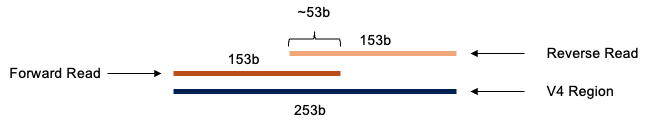

Read Merging Schematic

```r
merged_reads <- mergePairs(r1_dada, r1_filt, r2_dada, r2_filt, verbose=TRUE, minOverlap = 20)
```

```
118558 paired-reads (in 263 unique pairings) successfully merged out of 157060 (in 844 pairings) input.
```

```
136084 paired-reads (in 168 unique pairings) successfully merged out of 177647 (in 442 pairings) input.
```

```
121959 paired-reads (in 137 unique pairings) successfully merged out of 160808 (in 501 pairings) input.
```

```
147646 paired-reads (in 242 unique pairings) successfully merged out of 197543 (in 773 pairings) input.
```

```
136283 paired-reads (in 174 unique pairings) successfully merged out of 170506 (in 564 pairings) input.
```

```
107192 paired-reads (in 174 unique pairings) successfully merged out of 171796 (in 1236 pairings) input.
```

```
97054 paired-reads (in 79 unique pairings) successfully merged out of 169087 (in 290 pairings) input.
```

```
166079 paired-reads (in 151 unique pairings) successfully merged out of 221841 (in 390 pairings) input.
```

```
145220 paired-reads (in 257 unique pairings) successfully merged out of 202837 (in 921 pairings) input.
```

```
140775 paired-reads (in 330 unique pairings) successfully merged out of 197529 (in 1056 pairings) input.
```

```
114583 paired-reads (in 197 unique pairings) successfully merged out of 155831 (in 662 pairings) input.
```

```
113570 paired-reads (in 154 unique pairings) successfully merged out of 146691 (in 426 pairings) input.
```

```
166198 paired-reads (in 298 unique pairings) successfully merged out of 227484 (in 928 pairings) input.
```

```
132085 paired-reads (in 183 unique pairings) successfully merged out of 187488 (in 771 pairings) input.
```

```
197858 paired-reads (in 53 unique pairings) successfully merged out of 268009 (in 157 pairings) input.
```

```
177418 paired-reads (in 310 unique pairings) successfully merged out of 247694 (in 1028 pairings) input.
```

```
150880 paired-reads (in 359 unique pairings) successfully merged out of 215669 (in 1184 pairings) input.
```

```
175734 paired-reads (in 451 unique pairings) successfully merged out of 244011 (in 1410 pairings) input.
```

```
162257 paired-reads (in 803 unique pairings) successfully merged out of 214227 (in 2698 pairings) input.
```

```
189528 paired-reads (in 153 unique pairings) successfully merged out of 261741 (in 538 pairings) input.
```

```r
head(merged_reads[[1]])
```

```
                                                                                                                                                                                                                                                       sequence
1 TACGTAGGTGACAAGCGTTGTCCGGATTTATTGGGCGTAAAGGGAGCGCAGGCGGTCTGT…
2 TACAGAGGGTGCAAGCGTTAATCGGAATTACTGGGCGTAAAGCGCGCGTAGGTGGTTATT…
3 TACGTAGGTGACAAGCGTTGTCCGGATTTATTGGGCGTAAAGGGAGCGCAGGCGGTCTGT…
6 TACGTAGGGTGCAAGCGTTAATCGGAATTACTGGGCGTAAAGCGTGCGCAGGCGGTTGTG…
7 TACAGAGGGTGCAAGCGTTAATCGGAATTACTGGGCGTAAAGCGCGCGTAGGTGGTTTGT…
8 TACGTAGGTGGCAAGCGTTATCCGGAATTATTGGGCGTAAAGCGCGCGTAGGCGGTTTTT…
  abundance forward reverse nmatch nmismatch nindel prefer accept
1     50706       1       1     53         0      0      1   TRUE
2     10202       2       2     53         0      0      1   TRUE
3      8937       1       3     53         0      0      1   TRUE
6      6168       3       4     53         0      0      1   TRUE
7      5230       4       7     53         0      0      1   TRUE
8      4481       5       5     53         0      0      1   TRUE
```

**Quiz**

Let’s assume that you have a V1-V3 (~480bp) sequencing strategy with a 2x300 MiSeq run. On these types of runs, quality tends to decrease quite precipitously once you get to the ends of these longer reads, so you decide to trim at 270 on the forward reads and 230 on the reverse read (`truncLen = c(270,230)`).

What is the overlap length?

**Loss of reads at merged step**

Sometimes you might find that even though you’ve ensured sufficient overlap, there’s still a large number of reads lost at the merging step. This can happen for several reasons.

First, it can indicate that primers are indeed present in your data and may need trimming.

It could indicate that a filtering/trimming step needs to be better-optimized for your data (see above).

Losing some reads to merging is expected, but if you find you’re losing 50% or more, it might be worth diving in a little deeper.

## 8 Make Sequence Table

And finally we can make the first draft of our table!

```r
seq_table <- makeSequenceTable(merged_reads)
dim(seq_table)
```

```
[1]   20 2619
```

From this information, we can see that there are 20 rows for each of the 20 samples and there are columns for the 2619 sequence variants.

We can use basic R functions to explore the dataset, much like we would any table of counts.

Below is the distribution of the sequence lengths for our data. Notice that a large majority of sequences are 253 bases long, which is how long the V4 region is.

```r
table(nchar(getSequences(seq_table)))
```

```
 164  165  168  169  199  202  207  209  220  223  227  230  250  251  252  253
   3    3    3    3    1    1    1    1    1    1    2    2    4    3  295 2178
 254  255  266  268  276  279  280  285
 107    2    1    1    3    1    1    1
```

**Filter for sequence length!**

If you look at the table and find that you have sequences that are much larger or smaller than your target amplicon, you can remove them through basic R commands like: `filt_seq_table <- seq_table[, nchar(getSequences(seq_table)) %in% 250:255]`

These abnormal lengths can arise from non-specific priming and typically are not cause for concern.

## 9 Remove Chimeras

Chimeras are hybrids of two “parent” sequences, meaning that you have one bacterial sequence belonging to, say, *E. coli*, on one side of the read and another bacterial sequence belonging to *Streptococcus* on the other. These are typically due to the PCR process, and are considered artifacts that should be filtered out. We do that with the `removeBimeraDenovo` function, which checks lower abundance sequence variants against higher abundance sequence variants to determine if any match to two separate “parents”.

```r
chimera_check <- removeBimeraDenovo(seq_table, verbose=T)
```

```
Identified 1318 bimeras out of 2619 input sequences.
```

```r
dim(chimera_check)
```

```
[1]   20 1301
```

While we lose about half our sequences due to chimeras, we can determine how many reads were retained through this quick one-liner:

```r
sum(chimera_check)/sum(seq_table)
```

```
[1] 0.9791551
```

**Workflow Checkpoint!**

Let’s take a look at how our data looks so far in a nice, convenient table!

```r
getN <- function(x) sum(getUniques(x))
track <- cbind(out, sapply(r1_dada, getN), sapply(r2_dada, getN), sapply(merged_reads, getN), rowSums(chimera_check))
colnames(track) <- c("input","filtered","denoised_r1","denoised_r2","merged","nonchimeric")
track
```

```
                       input filtered denoised_r1 denoised_r2 merged
ERR5083021_1.fastq.gz 184105   158042      157821      157225 118558
ERR5083022_1.fastq.gz 215283   178461      178393      177704 136084
ERR5083023_1.fastq.gz 188345   161553      161364      160992 121959
ERR5083024_1.fastq.gz 228630   198805      198537      197747 147646
ERR5083025_1.fastq.gz 208557   171355      171138      170689 136283
ERR5083026_1.fastq.gz 221399   172853      172393      172229 107192
ERR5083027_1.fastq.gz 206371   169776      169563      169291  97054
ERR5083028_1.fastq.gz 258864   222554      222421      221961 166079
ERR5083029_1.fastq.gz 248457   204002      203617      203128 145220
ERR5083030_1.fastq.gz 232949   199106      198500      198098 140775
ERR5083031_1.fastq.gz 192017   156996      156541      156254 114583
ERR5083032_1.fastq.gz 182086   147473      147254      146893 113570
ERR5083033_1.fastq.gz 268647   228479      228161      227793 166198
ERR5083034_1.fastq.gz 237626   188624      188275      187830 132085
ERR5083035_1.fastq.gz 329348   268605      268436      268153 197858
ERR5083036_1.fastq.gz 289866   248908      248700      247865 177418
ERR5083037_1.fastq.gz 259349   216996      216489      216145 150880
ERR5083038_1.fastq.gz 283546   245068      244740      244263 175734
ERR5083039_1.fastq.gz 255232   215938      215493      214621 162257
ERR5083040_1.fastq.gz 318604   262531      262397      261852 189528
                      nonchimeric
ERR5083021_1.fastq.gz      117603
ERR5083022_1.fastq.gz      135350
ERR5083023_1.fastq.gz      120236
ERR5083024_1.fastq.gz      146897
ERR5083025_1.fastq.gz      135089
ERR5083026_1.fastq.gz      106010
ERR5083027_1.fastq.gz       96421
ERR5083028_1.fastq.gz      165702
ERR5083029_1.fastq.gz      141258
ERR5083030_1.fastq.gz      137064
ERR5083031_1.fastq.gz      113683
ERR5083032_1.fastq.gz      112657
ERR5083033_1.fastq.gz      163808
ERR5083034_1.fastq.gz      130145
ERR5083035_1.fastq.gz      196939
ERR5083036_1.fastq.gz      168846
ERR5083037_1.fastq.gz      145475
ERR5083038_1.fastq.gz      165917
ERR5083039_1.fastq.gz      148584
ERR5083040_1.fastq.gz      188890
```

As you can see, there was a slight loss of reads during filtering and merging for these particular samples. For now, there isn’t enough evidence that we need to double-check our workflow so far, but if the data ends up more problematic, this table might help target a step to focus on.

## 10 Assign Taxonomy

We now have 1301 sequence variants and we want to determine what bacteria they actually are. In order to do this, we need to download specially-formatted databases (you can find several different databases [here](https://benjjneb.github.io/dada2/training.html), some of which are contributed by outside teams). For our purposes, we’ll download the [SILVA database](https://zenodo.org/record/4587955)[^7]. You’ll need all three files and we’ll install them to a folder called `databases` that is in our working directory.

```r
taxa <- assignTaxonomy(chimera_check, "databases/silva_nr99_v138.1_train_set.fa.gz", multithread=F, verbose=T, minBoot = 80)
```

```
Finished processing reference fasta.
```

```r
taxa_print <- taxa
rownames(taxa_print) <- NULL
head(taxa_print,10)
```

```
      Kingdom    Phylum             Class                 Order
 [1,] "Bacteria" "Firmicutes"       "Bacilli"             "Lactobacillales"
 [2,] "Bacteria" "Proteobacteria"   "Gammaproteobacteria" "Pseudomonadales"
 [3,] "Bacteria" "Proteobacteria"   "Gammaproteobacteria" "Burkholderiales"
 [4,] "Bacteria" "Proteobacteria"   "Gammaproteobacteria" "Pseudomonadales"
 [5,] "Bacteria" "Firmicutes"       "Bacilli"             "Staphylococcales"
 [6,] "Bacteria" "Proteobacteria"   "Gammaproteobacteria" "Enterobacterales"
 [7,] "Bacteria" "Actinobacteriota" "Actinobacteria"      "Corynebacteriales"
 [8,] "Bacteria" "Firmicutes"       "Bacilli"             "Lactobacillales"
 [9,] "Bacteria" "Proteobacteria"   "Gammaproteobacteria" "Pseudomonadales"
[10,] "Bacteria" "Firmicutes"       "Bacilli"             "Lactobacillales"
      Family               Genus
 [1,] "Carnobacteriaceae"  "Dolosigranulum"
 [2,] "Moraxellaceae"      "Moraxella"
 [3,] "Chromobacteriaceae" "Chromobacterium"
 [4,] "Pseudomonadaceae"   "Pseudomonas"
 [5,] "Staphylococcaceae"  "Staphylococcus"
 [6,] "Pasteurellaceae"    "Haemophilus"
 [7,] "Corynebacteriaceae" "Corynebacterium"
 [8,] "Carnobacteriaceae"  "Dolosigranulum"
 [9,] "Moraxellaceae"      "Moraxella"
[10,] "Streptococcaceae"   "Streptococcus"
```

You’ll notice a parameter called `minBoot`, which is the minimum bootstrapped probability that the call is accurate. The default is 50. **Play** with different values. What do you notice about the specificity of the classifications? You may need to adjust the number of rows of `taxa_print` that are shown to be able to see some of these effects.

For today, we will only assign taxonomy to the genus level. Taxonomy assignment to the species level occurs using a separate function (`assignSpecies`), but is considered fully valid for DADA2 sequences. The method attempts to identify the genus and species independently and then only assigns species if the genus calls match. By default, `assignSpecies` will only do so if there is one unique species that reaches the criteria. However, there is also the option to list all species that match the sequence variant at 100% identity.

## 11 Make Phylogenetic Tree

Next, we align the sequences to each other so that we can create a phylogenetic tree. This tree can be used for statistical questions or visualizations later. As a disclaimer, there are a few additional steps needed to “optimize” the fit of the tree, but we won’t do them here because it can a long time. If you would like to explore this method of tree building further, you can find additional documentation [here](https://f1000research.com/articles/5-1492).

```r
library(DECIPHER)
library(phangorn)
seqs <- as.character(getSequences(chimera_check))
names(seqs) <- seqs
alignment <- DECIPHER::AlignSeqs(DNAStringSet(seqs), anchor=NA)
```

```
Determining distance matrix based on shared 8-mers:
================================================================================

Time difference of 9.72 secs

Clustering into groups by similarity:
================================================================================

Time difference of 0.12 secs

Aligning Sequences:
================================================================================

Time difference of 3.03 secs

Iteration 1 of 2:

Determining distance matrix based on alignment:
================================================================================

Time difference of 0.72 secs

Reclustering into groups by similarity:
================================================================================

Time difference of 0.15 secs

Realigning Sequences:
================================================================================

Time difference of 1.71 secs

Iteration 2 of 2:

Determining distance matrix based on alignment:
================================================================================

Time difference of 0.69 secs

Reclustering into groups by similarity:
================================================================================

Time difference of 0.15 secs

Realigning Sequences:
================================================================================

Time difference of 0.44 secs

Refining the alignment:
================================================================================

Time difference of 0.14 secs
```

```r
phang.align <- as.phyDat(as(alignment, "matrix"), type="DNA")
dm <- dist.ml(phang.align)
treeNJ <- NJ(dm)
fit <- pml(treeNJ, data=phang.align)
```

## 12 Generate a Phyloseq Object

Now we have the components we need to make an object that is compatible with various microbiome packages. These microbiome packages help bring the data to life and make both visualization and analysis much easier. My personal preference is [phyloseq](https://joey711.github.io/phyloseq/), but there are other packages out there that do the same or similar things, including [ampvis2](https://kasperskytte.github.io/ampvis2/articles/ampvis2.html) and SummarizedExperiment. I currently don’t have sample data on-hand for these samples, so we will make some dummy data first.

```r
library(phyloseq)
dummy_sample_data <- data.frame(samples=rownames(chimera_check), treatment_group=sample(c("A","B"), size=20, replace=TRUE))
rownames(dummy_sample_data) <- dummy_sample_data$samples
```

Now we import our components (OTU table, sample data, phylogenetic tree, and taxonomic table) into a single unified object:

```r
phy_obj <- phyloseq(otu_table(chimera_check, taxa_are_rows=F), sample_data(dummy_sample_data), phy_tree(fit$tree), tax_table(taxa))
phy_obj
```

```
phyloseq-class experiment-level object
otu_table()   OTU Table:         [ 1301 taxa and 20 samples ]
sample_data() Sample Data:       [ 20 samples by 2 sample variables ]
tax_table()   Taxonomy Table:    [ 1301 taxa by 6 taxonomic ranks ]
phy_tree()    Phylogenetic Tree: [ 1301 tips and 1299 internal nodes ]
```

With this new phyloseq object, we can perform visualizations. For example, we will create a bar plot and some PCoA plots.

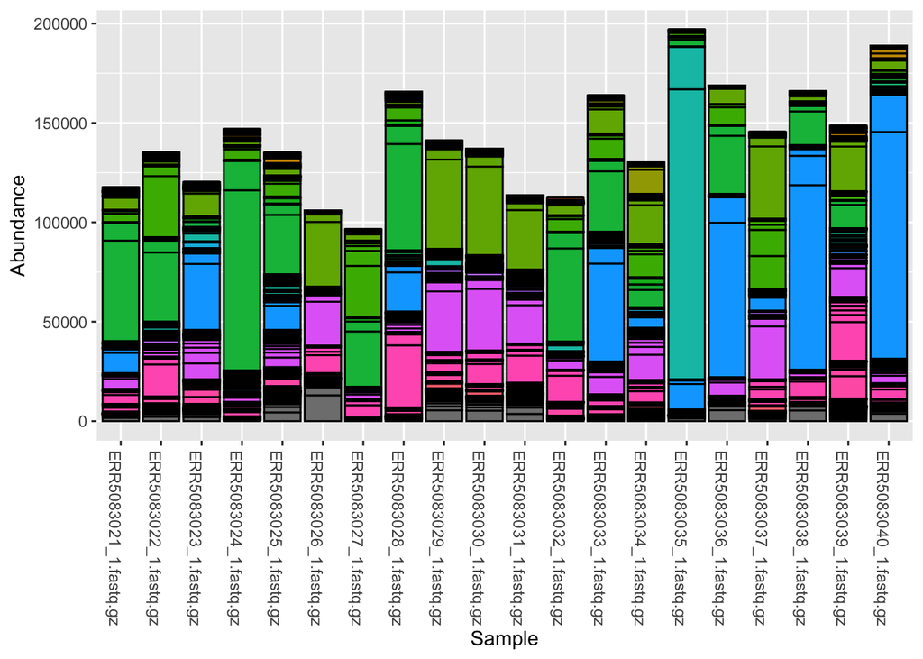

```r
library(ggplot2)
plot_bar(phy_obj, fill="Genus") + guides(fill="none")
```

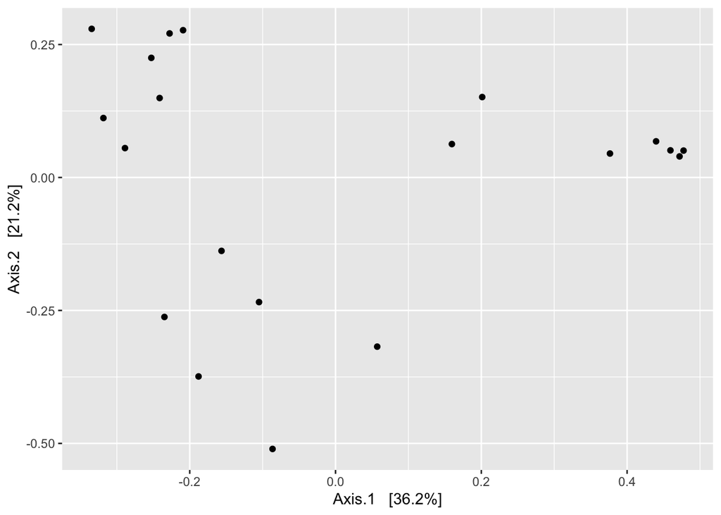

```r
ord <- ordinate(phy_obj, method="PCoA", distance = "bray")
plot_ordination(phy_obj, ord)
```

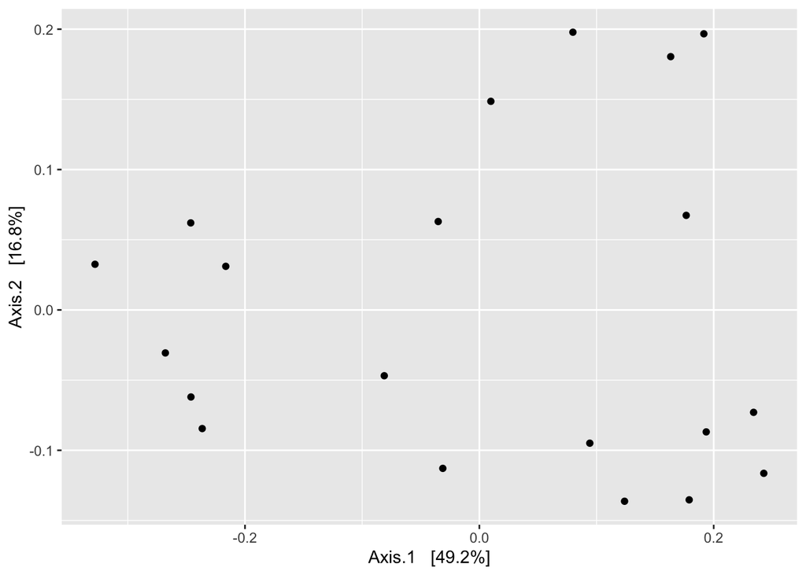

```r
ord <- ordinate(phy_obj, method="PCoA", distance = "wunifrac")
plot_ordination(phy_obj, ord)
```

## 13 Nephele

We can also process the data pretty much exactly the same way with Nephele. I have some jobs that I’ve already completed; feel free to review and experiment with them.

**QC**: a2e52d4e7445

**DADA2**: 4cac15889e25

If you want to re-run one of these jobs, visit the main Nephele page (nephele.niaid.nih.gov) and place the job IDs above into the “Need to re-run a Nephele job?” text box. Jobs remain available for 90 days, and I ran these on October 22, so they should be available for 3 more months.

As you review the results, you’ll notice that some specific tools or implementations are a bit different (ie, different phylogenetic tree builders, etc), but broadly the same techniques are applied.

## 14 Wrap-up

Thank you for joining today!

If you have feedback, ideas for additional sessions/trainings, questions about your own project, etc, feel free to reach out to me (kathryn.mccauley@nih.gov) or make a ticket to meet with the Bioinformatics team (go to bioinformatics.niaid.nih.gov and click “Start Your Project Today”); we would be happy to assist!

## Footnotes

[^1]: https://nephele.niaid.nih.gov/
[^2]: Callahan, B., McMurdie, P., Rosen, M. *et al.* DADA2: High-resolution sample inference from Illumina amplicon data. *Nat Methods* **13**, 581–583 (2016). https://doi.org/10.1038/nmeth.3869
[^3]: McCauley KE, Flynn K, Calatroni A, DiMassa V, LaMere B, Fadrosh DW, Lynch KV, Gill MA, Pongracic JA, Khurana Hershey GK, Kercsmar CM, Liu AH, Johnson CC, Kim H, Kattan M, O’Connor GT, Bacharier LB, Teach SJ, Gergen PJ, Wheatley LM, Togias A, LeBeau P, Presnell S, Boushey HA, Busse WW, Gern JE, Jackson DJ, Altman MC, Lynch SV; National Institute of Allergy and Infectious Diseases–sponsored Inner-City Asthma Consortium. Seasonal airway microbiome and transcriptome interactions promote childhood asthma exacerbations. J Allergy Clin Immunol. 2022 Jul;150(1):204-213. doi: 10.1016/j.jaci.2022.01.020. Epub 2022 Feb 8. PMID: 35149044.
[^4]: https://www.bioinformatics.babraham.ac.uk/projects/fastqc/
[^5]: Rosen MJ, Callahan BJ, Fisher DS, Holmes SP. Denoising PCR-amplified metagenome data. BMC Bioinformatics. 2012 Oct 31;13:283. doi: 10.1186/1471-2105-13-283. PMID: 23113967; PMCID: PMC3563472.
[^6]: Callahan BJ, Wong J, Heiner C, Oh S, Theriot CM, Gulati AS, McGill SK, Dougherty MK. High-throughput amplicon sequencing of the full-length 16S rRNA gene with single-nucleotide resolution. Nucleic Acids Res. 2019 Oct 10;47(18):e103. doi: 10.1093/nar/gkz569. PMID: 31269198; PMCID: PMC6765137.
[^7]: Quast C, Pruesse E, Yilmaz P, Gerken J, Schweer T, Yarza P, Peplies J, Glöckner FO (2013) The SILVA ribosomal RNA gene database project: improved data processing and web-based tools. Nucl. Acids Res. 41 (D1): D590-D596.